# Project 8 Template

```r
# Add to this package list for additional SL algorithms
gc(); rm(list=ls())
```

```
##          used (Mb) gc trigger (Mb) max used (Mb)
## Ncells 523706 28.0    1166054 62.3   660497 35.3
## Vcells 953704  7.3    8388608 64.0  1770414 13.6
```

```r
pacman::p_load(
  tidyverse,
  dplyr,
  ggthemes,
  ltmle,
  tmle,
  SuperLearner,
  tidymodels,
  caret,
  dagitty,
  ggdag,
  here,
  arm,
  xgboost,
  future)

heart_disease <- read_csv('heart_disease_tmle.csv') %>% tibble()
```

# Introduction

Heart disease is the leading cause of death in the United States, and treating it properly is an important public health goal. However, it is a complex disease with several different risk factors and potential treatments. Physicians typically recommend changes in diet, increased exercise, and/or medication to treat symptoms, but it is difficult to determine how effective any one of these factors is in treating the disease. In this project, you will explore SuperLearner, Targeted Maximum Likelihood Estimation (TMLE), and Longitudinal Targeted Maximum Likelihood Estimation (LTMLE). Using a simulated dataset, you will explore whether taking blood pressure medication reduces mortality risk.

# Data

For the “SuperLearner” and “TMLE” portions, you can ignore any variable that ends in “_2”, we will reintroduce these for LTMLE.

# SuperLearner

## Modeling

Fit a SuperLearner model to estimate the probability of someone dying from complications of heart disease, conditional on treatment and the relevant covariates. Do the following:

```r
# Fit SuperLearner Model

## sl lib
SL.library <- c("SL.glm", "SL.glmnet", "SL.bayesglm", "SL.randomForest", "SL.nnet",
                "SL.xgboost", "SL.nnet", "SL.knn", "SL.lda", "SL.ranger")



## Train/Test split
set.seed(123)
heart_split <- initial_split(heart_disease, prop = 3/4)



## Train SuperLearner
heart_train <- training(heart_split)

y_train <- heart_train %>% pull(mortality)
x_train <- heart_train %>%
  dplyr::select(-mortality, -matches(".*_2$"))


heart_test <- testing(heart_split)

y_test <- heart_test %>% pull(mortality)
x_test <- heart_test %>%
  dplyr::select(-mortality, -matches(".*_2$"))



## Risk and Coefficient of each model
superLL <- SuperLearner(Y = y_train,
                        X = x_train,
                        family = binomial(),
                        SL.library = SL.library)
superLL
```

```
##
## Call:
## SuperLearner(Y = y_train, X = x_train, family = binomial(), SL.library = SL.library)
##
##
##
##                          Risk       Coef
## SL.glm_All          0.2357025 0.00000000
## SL.glmnet_All       0.2356664 0.00000000
## SL.bayesglm_All     0.2356999 0.00000000
## SL.randomForest_All 0.2315994 0.05554043
## SL.nnet_All         0.2478574 0.02534190
## SL.xgboost_All      0.2500850 0.00000000
## SL.nnet_All         0.2494901 0.00000000
## SL.knn_All          0.2776735 0.00000000
## SL.lda_All          0.2356699 0.33504426
## SL.ranger_All       0.2312589 0.58407342
```

```r
## Discrete winner and superlearner ensemble performance
preds <- predict(superLL,
                 x_test,
                 onlySL = TRUE)

validation <- y_test %>%
  bind_cols(preds$pred[,1]) %>%
  rename(obs = `...1`,
         pred = `...2`) %>%
  mutate(pred = ifelse(pred >= 0.5, 1, 0))
head(validation)
```

| obs | pred |
| --- | --- |
| 1 | 1 |
| 1 | 0 |
| 0 | 1 |
| 1 | 1 |
| 1 | 1 |
| 0 | 0 |

```r
# Cross-validation across cores and Plot
cluster = parallel::makeCluster(availableCores() - 1)
parallel::clusterEvalQ(cluster, library(SuperLearner))
```

[output not shown]

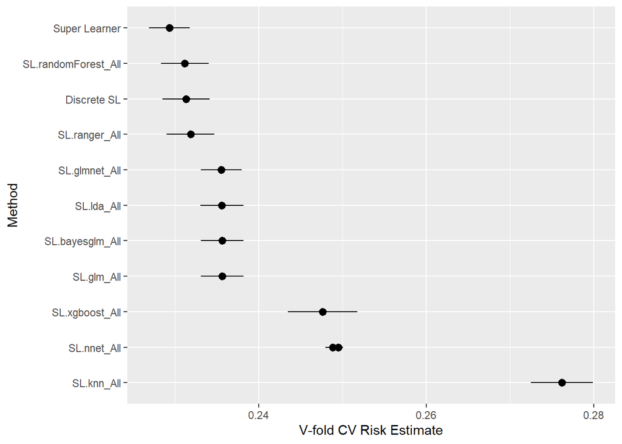

```r
parallel::clusterSetRNGStream(cluster, 1)


cv_superLL = CV.SuperLearner(Y = y_train,
                             X = x_train,
                             family = binomial(),
                             V = 20,
                             parallel = cluster,
                             SL.library = SL.library)
parallel::stopCluster(cluster)

plot(cv_superLL)
```

```r
## Confusion Matrix
CM <- caret::confusionMatrix(as.factor(validation$pred),
                             as.factor(validation$obs))
CM
```

```
## Confusion Matrix and Statistics
##
##           Reference
## Prediction    0    1
##          0  395  182
##          1  871 1052
##
##                Accuracy : 0.5788
##                  95% CI : (0.5592, 0.5983)
##     No Information Rate : 0.5064
##     P-Value [Acc > NIR] : 2.287e-13
##
##                   Kappa : 0.1634
##
##  Mcnemar's Test P-Value : < 2.2e-16
##
##             Sensitivity : 0.3120
##             Specificity : 0.8525
##          Pos Pred Value : 0.6846
##          Neg Pred Value : 0.5471
##              Prevalence : 0.5064
##          Detection Rate : 0.1580
##    Detection Prevalence : 0.2308
##       Balanced Accuracy : 0.5823
##
##        'Positive' Class : 0
##
```

```r
TP <- CM$table[2,2]
TN <- CM$table[1,1]
FP <- CM$table[2,1]
FN <- CM$table[1,2]

print(paste("accuracy: ", (TP+TN)/(TP+TN+FP+FN)))
```

```
## [1] "accuracy:  0.5788"
```

```r
print(paste("recall: ", TP/(TP+FN)))
```

```
## [1] "recall:  0.852512155591572"
```

```r
print(paste("precision: ", TP/(TP+FP)))
```

```
## [1] "precision:  0.547061882475299"
```

# Targeted Maximum Likelihood Estimation

## Causal Diagram

Using ggdag and daggity, draw a directed acylcic graph (DAG) that describes the relationships between the outcome, treatment, and covariates/predictors. Note, if you think there are covariates that are not related to other variables in the dataset, note this by either including them as freestanding nodes or by omitting them and noting omissions in your discussion.

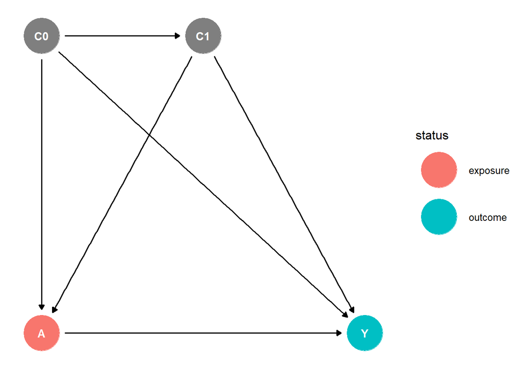

```r
# DAG for TMLE

dagify(Y ~ A + C0 + C1,
       A ~ C0 + C1,
       C1 ~ C0,
       exposure = "A",
       outcome = "Y",
       coords = list(x = c(A=1, C0=1, C1=2, Y=3),
                     y = c(A=1, C0=1.5, C1=1.5, Y=1))) %>%
  ggdag_status() +
  geom_dag_edges() +
  theme_dag()
```

```r
data.frame(
  Variable = c("A", "C0", "C1", "Y"),
  Description = c("BP Med (treatment)",
                  "Age, Sex, Race, Income, College Ed",
                  "BMI, Chol, BP",
                  "Mortality (outcome)"))
```

| Variable | Description |
| --- | --- |
| A | BP Med (treatment) |
| C0 | Age, Sex, Race, Income, College Ed |
| C1 | BMI, Chol, BP |
| Y | Mortality (outcome) |

## TMLE Estimation

Use the `tmle` package to estimate a model for the effect of blood pressure medication on the probability of mortality. Do the following:

```r
# Outcome
Y <- heart_disease %>%
  pull(mortality)

A <- heart_disease %>%
  pull(blood_pressure_medication)

W <- heart_disease %>%
  dplyr::select(-mortality, -blood_pressure_medication, -matches(".*_2$"))

#SL.library <- c("SL.glm", "SL.bayesglm", "SL.glmnet", "SL.randomForest", "SL.xgboost", "SL.nnet", "SL.knn")
SL.library2 <- c('SL.glmnet', 'SL.ranger', 'SL.glm')
tmle_fit <- tmle::tmle(Y = Y,
                       A = A,
                       W = W,
                       Q.SL.library = SL.library2,
                       g.SL.library = SL.library2)
tmle_fit
```

```
##  Additive Effect
##    Parameter Estimate:  -0.3542
##    Estimated Variance:  6.3284e-05
##               p-value:  <2e-16
##     95% Conf Interval:  (-0.36979, -0.3386)
##
##  Additive Effect among the Treated
##    Parameter Estimate:  -0.31987
##    Estimated Variance:  0.00014504
##               p-value:  <2e-16
##     95% Conf Interval:  (-0.34348, -0.29627)
##
##  Additive Effect among the Controls
##    Parameter Estimate:  -0.37182
##    Estimated Variance:  5.5899e-05
##               p-value:  <2e-16
##     95% Conf Interval:  (-0.38647, -0.35717)
```

```r
summary(tmle_fit)
```

```
##  Initial estimation of Q
##   Procedure: cv-SuperLearner, ensemble
##   Model:
##       Y ~  SL.glmnet_All + SL.ranger_All + SL.glm_All
##
##   Coefficients:
##     SL.glmnet_All    0.2932814
##     SL.ranger_All    0.7067186
##        SL.glm_All    0
##
##   Cross-validated R squared :  0.0834
##
##  Estimation of g (treatment mechanism)
##   Procedure: SuperLearner, ensemble
##   Model:
##       A ~  SL.glmnet_All + SL.ranger_All + SL.glm_All
##
##   Coefficients:
##     SL.glmnet_All    0.7272909
##     SL.ranger_All    0.1747352
##        SL.glm_All    0.09797395
##
##  Estimation of g.Z (intermediate variable assignment mechanism)
##   Procedure: No intermediate variable
##
##  Estimation of g.Delta (missingness mechanism)
##   Procedure: No missingness, ensemble
##
##  Bounds on g: (0.0054, 1)
##
##  Bounds on g for ATT/ATE: (0.0054, 0.9946)
##
##  Additive Effect
##    Parameter Estimate:  -0.3542
##    Estimated Variance:  6.3284e-05
##               p-value:  <2e-16
##     95% Conf Interval:  (-0.36979, -0.3386)
##
##  Additive Effect among the Treated
##    Parameter Estimate:  -0.31987
##    Estimated Variance:  0.00014504
##               p-value:  <2e-16
##     95% Conf Interval:  (-0.34348, -0.29627)
##
##  Additive Effect among the Controls
##    Parameter Estimate:  -0.37182
##    Estimated Variance:  5.5899e-05
##               p-value:  <2e-16
##     95% Conf Interval:  (-0.38647, -0.35717)
```

# LTMLE Estimation

Now imagine that everything you measured up until now was in “time period 1”. Some people either choose not to or otherwise lack access to medication in that time period, but do start taking the medication in time period 2. Imagine we measure covariates like BMI, blood pressure, and cholesterol at that time for everyone in the study (indicated by a “_2” after the covariate name).

## Causal Diagram

Update your causal diagram to incorporate this new information. : If your groups divides up sections and someone is working on LTMLE separately from TMLE then just draw a causal diagram even if it does not match the one you specified above.

: Check out slide 27 from Maya’s lecture, or slides 15-17 from Dave’s second slide deck in week 8 on matching.

: Keep in mind that any of the variables that end in “_2” are likely affected by both the previous covariates and the first treatment when drawing your DAG.

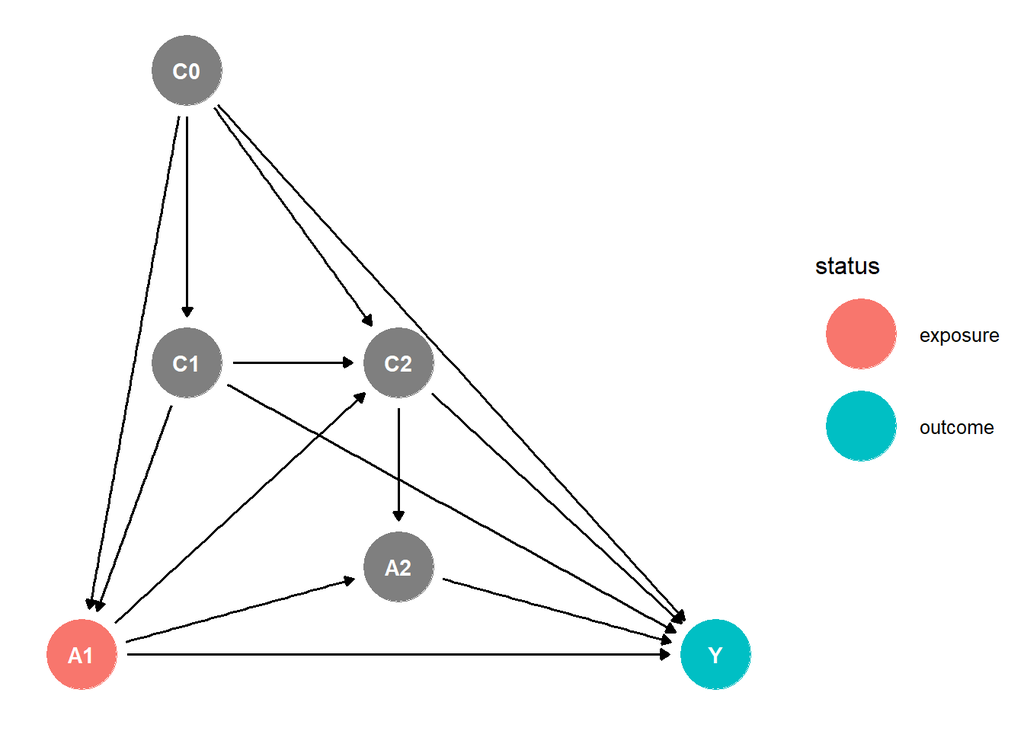

```r
# DAG for TMLE

dagify(Y ~ A1 + A2 + C0 + C1 + C2,
       A2 ~ A1 + C2,
       A1 ~ C0 +C1,
       C2 ~ A1 + C0 + C1,
       C1 ~ C0,
       exposure = "A1",
       outcome = "Y",
       coords = list(x = c(A1=1, C0=1.5, C1=1.5, C2=2.5, A2=2.5, Y=4),
                     y = c(A1=1, C0=3, C1=2, C2=2, A2=1.3, Y=1))) %>%
  ggdag_status() +
  geom_dag_edges() +
  theme_dag()
```

```r
data.frame(
  Variable = c("A1", "A2", "C0", "C1", "C2", "Y"),
  Description = c("BP Med (treatment)",
                  "BP Med_2 (treatment)",
                  "Age, Sex, Race, Income, College Ed",
                  "BMI, Chol, BP",
                  "BMI_2, Chol_2, BP_2",
                  "Mortality (outcome)"))
```

| Variable | Description |
| --- | --- |
| A1 | BP Med (treatment) |
| A2 | BP Med_2 (treatment) |
| C0 | Age, Sex, Race, Income, College Ed |
| C1 | BMI, Chol, BP |
| C2 | BMI_2, Chol_2, BP_2 |
| Y | Mortality (outcome) |

## LTMLE Estimation

```r
## Naive Model (no time-dependent confounding) estimate

A1 <- heart_disease %>% pull(blood_pressure_medication)
A2 <- heart_disease %>% pull(blood_pressure_medication_2)

C0_1 <- heart_disease %>% pull(age)
C0_2 <- heart_disease %>% pull(sex_at_birth)
C0_3 <- heart_disease %>% pull(simplified_race)
C0_4 <- heart_disease %>% pull(college_educ)
C0_5 <- heart_disease %>% pull(income_thousands)

C1_1 <- heart_disease %>% pull(bmi)
C1_2 <- heart_disease %>% pull(blood_pressure)
C1_3 <- heart_disease %>% pull(chol)

C2_1 <- heart_disease %>% pull(bmi_2)
C2_2 <- heart_disease %>% pull(blood_pressure_2)
C2_3 <- heart_disease %>% pull(chol_2)

Y <- heart_disease %>% pull(mortality)

data1 <- data.frame(C0_1,C0_2,C0_3,C0_4,C0_5,A1,A2,Y)
data2 <- data.frame(C0_1,C0_2,C0_3,C0_4,C0_5,C1_1,C1_2,C1_3,C2_1,C2_2,C2_3,A1,A2,Y)

result1_1 <- glm(Y ~ A1+A2, data = data1)

result1_2 <- ltmle(data1,
                  Anodes = c("A1","A2"),
                  Lnodes = NULL,
                  Ynodes = "Y",
                  abar = c(1, 1),
                  SL.library = SL.library2
                  )
```

```
## Qform not specified, using defaults:
```

```
## formula for Y:
```

```
## Q.kplus1 ~ C0_1 + C0_2 + C0_3 + C0_4 + C0_5 + A1 + A2
```

```
## gform not specified, using defaults:
```

```
## formula for A1:
```

```
## A1 ~ C0_1 + C0_2 + C0_3 + C0_4 + C0_5
```

```
## formula for A2:
```

```
## A2 ~ C0_1 + C0_2 + C0_3 + C0_4 + C0_5 + A1
```

```
## Estimate of time to completion: 3 to 11 minutes
```

```r
result1_1$coefficients[1]
```

```
## (Intercept)
##   0.5657497
```

```r
result2 <- ltmle(data2,
                 Anodes = c("A1", "A2"),
                 Lnodes = c("C1_1", "C1_2", "C1_3","C2_1", "C2_2", "C2_3"),
                 Ynodes = "Y",
                 gform = c("A1 ~ C1_1 + C1_2 + C1_3",
                            "A2 ~ A1 + C2_1 + C2_2 + C2_3"),
                 abar = c(1, 1),
                 SL.library = SL.library2
                 )
```

```
## Qform not specified, using defaults:
```

```
## formula for Y:
```

```
## Q.kplus1 ~ C0_1 + C0_2 + C0_3 + C0_4 + C0_5 + C1_1 + C1_2 + C1_3 +     C2_1 + C2_2 + C2_3 + A1 + A2
```

```
## Estimate of time to completion: 3 to 12 minutes
```

```r
dif_val_1 <- round(result1_1$coefficients[2] - result2$estimates[1], 4)
dif_val_2 <- round(result1_2$estimates[1] - result2$estimates[1], 4)

print(paste("Difference in Naive and LTMLE estimate :",dif_val_1))
```

```
## [1] "Difference in Naive and LTMLE estimate : -0.7086"
```

```r
print(paste("Difference in TMLE estimates:", dif_val_2))
```

```
## [1] "Difference in TMLE estimates: -0.1308"
```